# E-Commerce Shopping Behaviour Analysis

1. **Business Overview**
2. **Load and explore the Dataset**
3. **Data Cleaning & Preprocessing**
4. **Exploratory Data Analysis (EDA)**
   - Q1: How does Age influence Purchase Amount?
   - Q2: Do males and females prefer different product categories?
   - Q3: Which product categories are most popular in different seasons?
   - Q4: Do discounts or promo codes actually increase purchase amounts?
   - Q5: Does subscription status affect purchase frequency and spending?
   - Q6: Which payment methods are most popular, and do they affect spending?
   - Q7: Which locations generate the highest sales?
5. **Final conclusionn & Suggestions for business**
6. **Reference of the source of dataset**

# E-Commerce Shopping Behaviour Analysis

## 1. Business Overview

Our client is an **E-commerce company** that sells a variety of products across different categories such as clothing, footwear, and accessories. With increasing competition in the online shopping industry the company wants to **better understand customer behaviour** in order to

- Improve sales and marketing strategies
- Optimize discounts, promo codes and subscription programs
- Personalize product recommendations
- Identify seasonal and regional shopping trends

### About the Dataset

the dataset contains **3900 customer records** with **18 attributes** that describe demographics, purchase details, and shopping habits. key features include:

- **Customer demographics:** Age, Gender, Location
- **Purchase details:** Item, Category, Size, Color, Season, Purchase Amount
- **Behavioural data:** Frequency of Purchases, Previous Purchases, Subscription Status
- **Promotional factors:** Discounts, Promo Codes
- **Transaction details:** Payment Method, Shipping Type
- **Feedback:** Review Ratings

### Why This Analysis?

As data scientists, our task is to help the company **gain actionable insights** from this dataset. Through **Exploratory Data Analysis (EDA)**, we will uncover trends such as:

- How age, gender, and location influence shopping preferences
- Which product categories are most popular during different seasons
- The effect of discounts and subscriptions on spending behaviour
- Customer loyalty patterns and payment preferences

These insights will support **data-driven decision-making**, allowing the company to increase customer satisfaction and maximize revenue.

### Reference

```python
#importing the libraries
import pandas as pd
import numpy as np
import matplotlib.pyplot as plt
import seaborn as sns
import warnings
warnings.filterwarnings("ignore")
```

STEP-02 LOADING THE DATASET AND EXPLORE

```python
#loading the dataset
df = pd.read_csv("/content/shopping_behaviour_wholedata.csv")
```

```python
df.head()
```

|  | Customer ID | Age | Gender | Item Purchased | Category | Purchase Amount (USD) | Location | Size | Color | Season | Review Rating | Subscription Status | Shipping Type | Discount Applied | Promo Code Used | Previous Purchases | Payment Method | Frequency of Purchases |
| --- | --- | --- | --- | --- | --- | --- | --- | --- | --- | --- | --- | --- | --- | --- | --- | --- | --- | --- |
| 0 | 1 | 55.0 | Male | Blouse | Clothing | 53.0 | Kentucky | L | Gray | Winter | 3.1 | Yes | Express | Yes | Yes | 14 | Venmo | Fortnightly |
| 1 | 2 | 19.0 | Male | Sweater | Clothing | 64.0 | Maine | L | Maroon | Winter | 3.1 | Yes | Express | Yes | Yes | 2 | Cash | Fortnightly |
| 2 | 3 | 50.0 | Male | Jeans | Clothing | 73.0 | Massachusetts | S | Maroon | Spring | 3.1 | Yes | Free Shipping | Yes | Yes | 23 | Credit Card | Weekly |
| 3 | 4 | 21.0 | Male | Sandals | Footwear | NaN | Rhode Island | M | Maroon | Spring | 3.5 | Yes | Next Day Air | Yes | Yes | 49 | PayPal | Weekly |
| 4 | 5 | 45.0 | Male | Blouse | Clothing | 49.0 | Oregon | M | Turquoise | Spring | 2.7 | Yes | Free Shipping | Yes | Yes | 31 | PayPal | Annually |

```python
df.info()
```

```
<class 'pandas.core.frame.DataFrame'>
RangeIndex: 3930 entries, 0 to 3929
Data columns (total 18 columns):
 #   Column                  Non-Null Count  Dtype
---  ------                  --------------  -----
 0   Customer ID             3930 non-null   int64
 1   Age                     3851 non-null   float64
 2   Gender                  3930 non-null   object
 3   Item Purchased          3930 non-null   object
 4   Category                3930 non-null   object
 5   Purchase Amount (USD)   3811 non-null   float64
 6   Location                3930 non-null   object
 7   Size                    3930 non-null   object
 8   Color                   3930 non-null   object
 9   Season                  3930 non-null   object
 10  Review Rating           3735 non-null   float64
 11  Subscription Status     3930 non-null   object
 12  Shipping Type           3930 non-null   object
 13  Discount Applied        3930 non-null   object
 14  Promo Code Used         3930 non-null   object
 15  Previous Purchases      3930 non-null   int64
 16  Payment Method          3930 non-null   object
 17  Frequency of Purchases  3930 non-null   object
dtypes: float64(3), int64(2), object(13)
memory usage: 552.8+ KB
```

```python
print(" Before Cleaning:")
print("Rows & Columns:", df.shape)
```

```
 Before Cleaning:
Rows & Columns: (3930, 18)
```

```python
print("Missing values per column:\n", df.isnull().sum())
print("Duplicate rows:", df.duplicated().sum())
```

```
Missing values per column:
 Customer ID                 0
Age                        79
Gender                      0
Item Purchased              0
Category                    0
Purchase Amount (USD)     119
Location                    0
Size                        0
Color                       0
Season                      0
Review Rating             195
Subscription Status         0
Shipping Type               0
Discount Applied            0
Promo Code Used             0
Previous Purchases          0
Payment Method              0
Frequency of Purchases      0
dtype: int64
Duplicate rows: 30
```

STEP- 03 CLEANING THE DATASET

```python
# 1. Handle Missing Values

# Strategy:
# - For Age → fill with median (better than mean, less affected by outliers)
# - For Purchase Amount → fill with median
# - For Review Rating → fill with mode (most common rating)

df['Age'].fillna(df['Age'].median(), inplace=True)
df['Purchase Amount (USD)'].fillna(df['Purchase Amount (USD)'].median(), inplace=True)
df['Review Rating'].fillna(df['Review Rating'].mode()[0], inplace=True)
```

```python
# 2. Remove Duplicates

df.drop_duplicates(inplace=True)


# 3. Fix Inconsistent Categorical Values

# Standardize Gender column (capitalize first letter)
df['Gender'] = df['Gender'].str.capitalize()
```

```python
# Purchase Amount should not be negative → convert to absolute value
df['Purchase Amount (USD)'] = df['Purchase Amount (USD)'].abs()
```

```python
#5. Verify Cleaning
# -----------------------------
print("\n🔹 After Cleaning:")
print("Rows & Columns:", df.shape)
print("Missing values per column:\n", df.isnull().sum())
print("Duplicate rows:", df.duplicated().sum())
print("\nUnique values in Gender:", df['Gender'].unique())
```

```
🔹 After Cleaning:
Rows & Columns: (3900, 18)
Missing values per column:
 Customer ID               0
Age                       0
Gender                    0
Item Purchased            0
Category                  0
Purchase Amount (USD)     0
Location                  0
Size                      0
Color                     0
Season                    0
Review Rating             0
Subscription Status       0
Shipping Type             0
Discount Applied          0
Promo Code Used           0
Previous Purchases        0
Payment Method            0
Frequency of Purchases    0
dtype: int64
Duplicate rows: 0

Unique values in Gender: ['Male' 'Female']
```

```python
df.columns
```

```
Index(['Customer ID', 'Age', 'Gender', 'Item Purchased', 'Category',
       'Purchase Amount (USD)', 'Location', 'Size', 'Color', 'Season',
       'Review Rating', 'Subscription Status', 'Shipping Type',
       'Discount Applied', 'Promo Code Used', 'Previous Purchases',
       'Payment Method', 'Frequency of Purchases'],
      dtype='object')
```

STEP-04 BUSINESS QUESTIONS FOR EDA

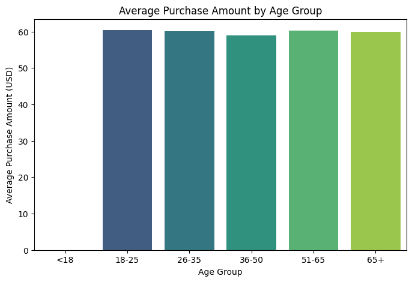

|  | Age Group | Purchase Amount (USD) |
| --- | --- | --- |
| 0 | <18 | NaN |
| 1 | 18-25 | 60.426778 |
| 2 | 26-35 | 60.122973 |
| 3 | 36-50 | 59.008696 |
| 4 | 51-65 | 60.199282 |
| 5 | 65+ | 59.873206 |

```python
#Question 1 -How does Age influence customer spending (Purchase Amount)?



# Create Age Groups for better comparison
bins = [0, 18, 25, 35, 50, 65, 100]
labels = ['<18', '18-25', '26-35', '36-50', '51-65', '65+']
df['Age Group'] = pd.cut(df['Age'], bins=bins, labels=labels, right=False)

# Average spending per age group
age_spending = df.groupby('Age Group')['Purchase Amount (USD)'].mean().reset_index()

# Plot the result
plt.figure(figsize=(8,5))
sns.barplot(x='Age Group', y='Purchase Amount (USD)', data=age_spending, palette='viridis')
plt.title("Average Purchase Amount by Age Group")
plt.ylabel("Average Purchase Amount (USD)")
plt.xlabel("Age Group")
plt.show()

# Display table
age_spending
```

Business Insight: If, for example, the 26–35 group spends the most, the company should target them with premium offers or loyalty programs. Younger groups might need discounts to increase spending.

```python
#Question 2 -Do males and females prefer different product categories?
```

[figure not shown]

[output not shown]

```python
# Count of purchases by Gender and Category
gender_category = df.groupby(['Gender', 'Category']).size().reset_index(name='Count')

# Plot
plt.figure(figsize=(10,6))
sns.barplot(x='Category', y='Count', hue='Gender', data=gender_category, palette='Set2')
plt.title("Product Category Preferences by Gender")
plt.ylabel("Number of Purchases")
plt.xlabel("Product Category")
plt.xticks(rotation=30)
plt.show()

# Show summary table
gender_category.sort_values(by='Count', ascending=False).head(10)
```

Business Insight:

If females dominate clothing sales → push more fashion ads toward women.

If males buy more in certain categories → highlight those in male-targeted campaigns.

The company can personalize homepage banners and email marketing based on gender shopping behaviour

```python
#Question 3 -Which product categories are most popular in different seasons?
```

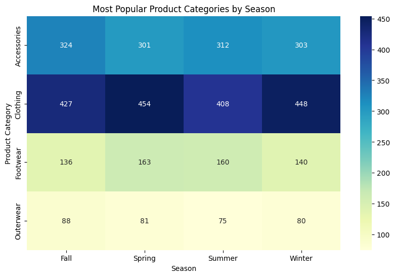

```python
# Pivot table for season vs category
season_pivot = df.pivot_table(index='Category', columns='Season',
                              values='Customer ID', aggfunc='count').fillna(0)

# Heatmap visualization
plt.figure(figsize=(10,6))
sns.heatmap(season_pivot, annot=True, fmt=".0f", cmap="YlGnBu")
plt.title("Most Popular Product Categories by Season")
plt.ylabel("Product Category")
plt.xlabel("Season")
plt.show()
```

Explanation (student-style) I made a heatmap where each cell shows how many items of a category were bought in a season.

Darker color = more purchases, lighter = less. This lets us quickly spot patterns. Business Insight:

Example: Winter → Jackets/Coats more popular.

Summer → T-shirts/Footwear in demand.

Company can stock the right products for each season and run seasonal ads.

Question 4

Do discounts or promo codes actually increase purchase amounts?

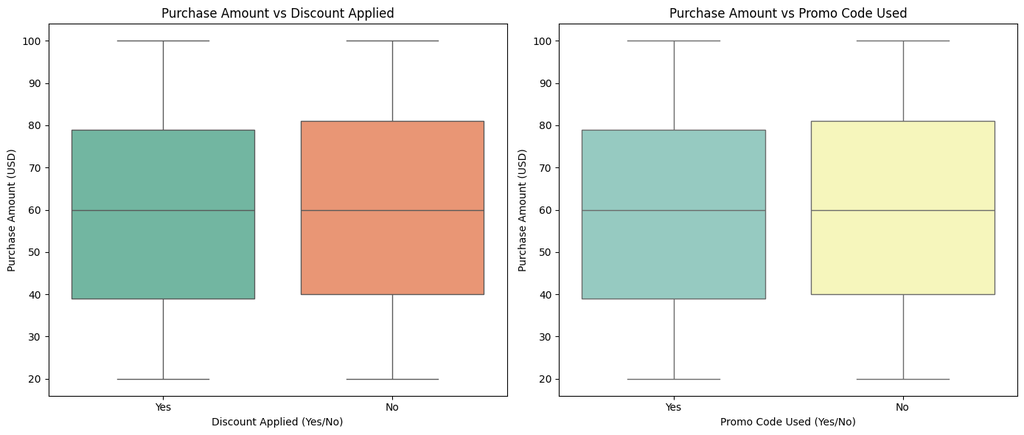

```python
fig, axes = plt.subplots(1, 2, figsize=(14,6))

# Boxplot for Discount Applied
sns.boxplot(x='Discount Applied', y='Purchase Amount (USD)', data=df, ax=axes[0], palette='Set2')
axes[0].set_title("Purchase Amount vs Discount Applied")
axes[0].set_xlabel("Discount Applied (Yes/No)")
axes[0].set_ylabel("Purchase Amount (USD)")

# Boxplot for Promo Code Used
sns.boxplot(x='Promo Code Used', y='Purchase Amount (USD)', data=df, ax=axes[1], palette='Set3')
axes[1].set_title("Purchase Amount vs Promo Code Used")
axes[1].set_xlabel("Promo Code Used (Yes/No)")
axes[1].set_ylabel("Purchase Amount (USD)")

plt.tight_layout()
plt.show()
```

Explanation A boxplot shows how purchase amounts are spread for two groups:

With vs Without Discounts

With vs Without Promo Codes

If the boxes are higher for “Yes”, it means people spend more when discounts/promo codes are applied.

If they’re lower, it means people are just buying cheaper items with discounts.

Business Insight:

If discounts increase total spending, keep offering them.

If not, promotions might only cut profit margins → better to reduce them.

**Business Question 5**

Does subscription status affect purchase frequency and spending?

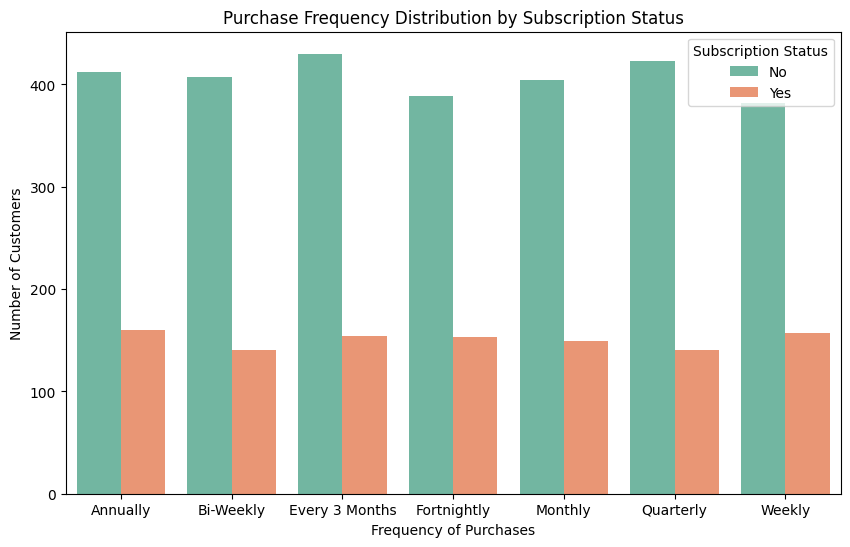

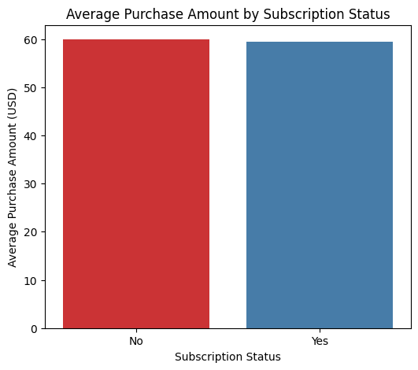

|  | Subscription Status | Purchase Amount (USD) |
| --- | --- | --- |
| 0 | No | 59.944152 |
| 1 | Yes | 59.509022 |

```python
# Business Question 5: Subscription Status vs Frequency & Spending (Fixed)

# 1. Count of frequency categories by subscription status
freq_counts = df.groupby(['Subscription Status', 'Frequency of Purchases']).size().reset_index(name='Count')

# Plot count of frequency levels
plt.figure(figsize=(10,6))
sns.barplot(x='Frequency of Purchases', y='Count', hue='Subscription Status', data=freq_counts, palette='Set2')
plt.title("Purchase Frequency Distribution by Subscription Status")
plt.ylabel("Number of Customers")
plt.xlabel("Frequency of Purchases")
plt.show()

# 2. Average purchase amount by subscription status
subscription_spending = df.groupby('Subscription Status')['Purchase Amount (USD)'].mean().reset_index()

# Plot average spending
plt.figure(figsize=(6,5))
sns.barplot(x='Subscription Status', y='Purchase Amount (USD)', data=subscription_spending, palette='Set1')
plt.title("Average Purchase Amount by Subscription Status")
plt.ylabel("Average Purchase Amount (USD)")
plt.show()

subscription_spending
```

Subscribers are compared with non-subscribers in terms of purchase frequency and spending.